# Top Plotting Tips

R Ladies Nijmegen

28 maart 2019

## Some announcements!

- New R-Ladies chapter in Den Bosch!
- We are looking for co-organizers!
- We are looking for funding!

## Why are some plots easier to read than others?

Vision doesn’t come for free. One whole lobe of our brains (occipital lobe, in the back) is dedicated primarily to processing what we see.

Humans are good at:

- Seeing adjacent light/dark contrasts
- Seeing angles of lines
  - Why: Early parts of the visual stream are dedicated to contrast & orientation
- Telling that one thing is very big
- Finding one relevant detail at a time
  - Why: The eye only sees 5 degrees of visual angle at a time, & the brain fills in the rest
  - Highest acuity = 1-2 degree spot (=1-2 thumb widths at arm’s length)

## The role of visual attention

Your brain binds discrete visual properties together to show you a cohesive world.

Combinations of things – relations – take cognitive work.

- Make plots as simple as possible to convey the required information.

Single features like color, orientation (A,B,D) lead to ‘pop-out’ unlike feature combinations (C,E,F)

- Use single shapes, not relations between them (line plots > bar plots)

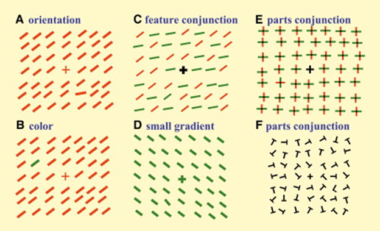

*Figure from Hochstien & Ahissar, 2002*

## Color can also be mis-percieved

- Even a person with perfect color vision percieves green best.

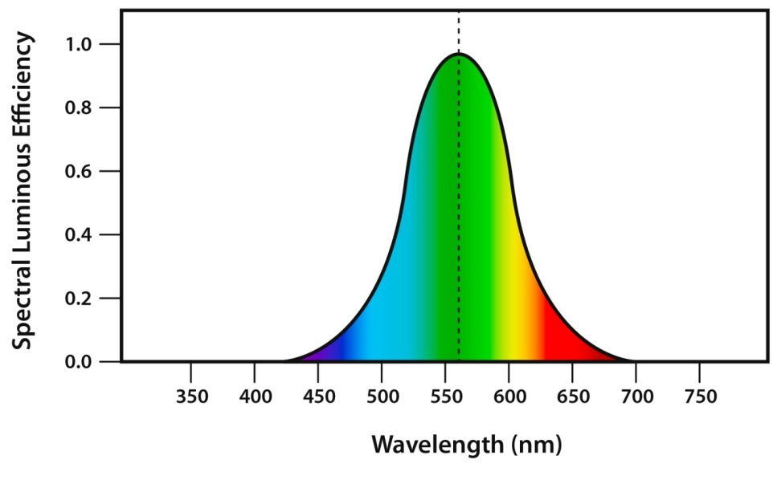

*http://www.npl.co.uk/…/the-eyes-response-to-colour/*

- And 8% of people have anomalous color vision.

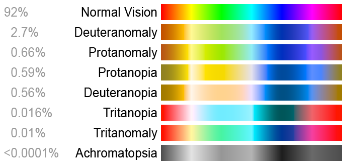

*wikimedia commons: Color_blindness.png/*

## So, what to do?

Make a plot that is as simple as possible but portrays the data *accurately*

- Convey main trends, and also variability around them
  - Use color to emphasize main points. Use grey to emphasize contrast set.
- Don’t make the reader use relational reasoning
  - Portray changes as lines.
  - Make important comparisons nearby in the plot, so the relational reasoning is easier.
- Don’t force the reader to make impossible color contrasts
  - Red vs blue, or light vs dark > red vs green, light vs also light
  - see [colorbrewer](http://colorbrewer2.org/#type=diverging&scheme=BrBG&n=3) for pretty palettes that can be colorblind safe and printer friendly

## How to choose your plot?

Here’s a nice infographic of many plotting options:

```
www.ft.com/vocabulary
```

For our purposes, focus on graphs for:

- Correlation
- Time series (change over time)
- Distribution
- Part-to-whole (bar plots and the like)

Data are all in-built R datasets. See data() for more info! (If you have ggplot2 downloaded, you should be able to run this code)

## Correlation plots

These ask the question:

“How does Y change as a function of X”?

(Relationship between two or more linear variables)

## Scatterplot

X vs Y

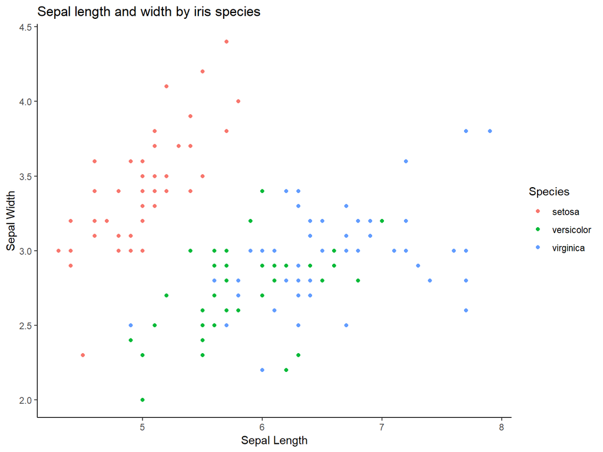

```r
ggplot(data=iris,aes(x=Sepal.Length,y=Sepal.Width,color=Species)) +
  geom_point() + theme_classic() +
  ggtitle("Sepal length and width by iris species") +
  ylab("Sepal Width") + xlab("Sepal Length")
```

## Bubble plot

X vs Y and Z

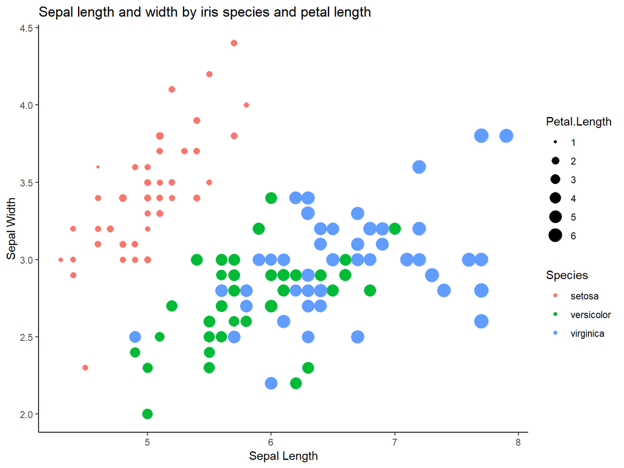

```r
ggplot(data=iris,aes(x=Sepal.Length,y=Sepal.Width,
                     size=Petal.Length,color=Species)) +
  geom_point() + theme_classic() +
  ggtitle("Sepal length and width by iris species and petal length") +
  ylab("Sepal Width") + xlab("Sepal Length")
```